# Marketing report part 1

Authors

Luis Francisco Gomez Lopez

Published

April 20, 2024

# 1 Describing data

## 1.2 Import data

```r
# Import the data from the sweep package
bike_sales <- bike_sales
bike_sales |> head()
```

```
# A tibble: 6 × 17
  order.date order.id order.line quantity price price.ext customer.id
  <date>        <dbl>      <int>    <dbl> <dbl>     <dbl>       <dbl>
1 2011-01-07        1          1        1  6070      6070           2
2 2011-01-07        1          2        1  5970      5970           2
3 2011-01-10        2          1        1  2770      2770          10
4 2011-01-10        2          2        1  5970      5970          10
5 2011-01-10        3          1        1 10660     10660           6
6 2011-01-10        3          2        1  3200      3200           6
# ℹ 10 more variables: bikeshop.name <chr>, bikeshop.city <chr>,
#   bikeshop.state <chr>, latitude <dbl>, longitude <dbl>, product.id <dbl>,
#   model <chr>, category.primary <chr>, category.secondary <chr>, frame <chr>
```

## 1.3 Inspect data

Use the available functions from base R or the `tidyverse` to inspect the data

```r
bike_sales |> glimpse()
```

```
Rows: 15,644
Columns: 17
$ order.date         <date> 2011-01-07, 2011-01-07, 2011-01-10, 2011-01-10, 20…
$ order.id           <dbl> 1, 1, 2, 2, 3, 3, 3, 3, 3, 4, 5, 5, 5, 5, 6, 6, 6, …
$ order.line         <int> 1, 2, 1, 2, 1, 2, 3, 4, 5, 1, 1, 2, 3, 4, 1, 2, 3, …
$ quantity           <dbl> 1, 1, 1, 1, 1, 1, 1, 1, 1, 1, 1, 8, 1, 1, 1, 1, 1, …
$ price              <dbl> 6070, 5970, 2770, 5970, 10660, 3200, 12790, 5330, 1…
$ price.ext          <dbl> 6070, 5970, 2770, 5970, 10660, 3200, 12790, 5330, 1…
$ customer.id        <dbl> 2, 2, 10, 10, 6, 6, 6, 6, 6, 22, 8, 8, 8, 8, 16, 16…
$ bikeshop.name      <chr> "Ithaca Mountain Climbers", "Ithaca Mountain Climbe…
$ bikeshop.city      <chr> "Ithaca", "Ithaca", "Kansas City", "Kansas City", "…
$ bikeshop.state     <chr> "NY", "NY", "KS", "KS", "KY", "KY", "KY", "KY", "KY…
$ latitude           <dbl> 42.44396, 42.44396, 39.11405, 39.11405, 38.25267, 3…
$ longitude          <dbl> -76.50188, -76.50188, -94.62746, -94.62746, -85.758…
$ product.id         <dbl> 48, 52, 76, 52, 2, 50, 1, 4, 34, 26, 96, 66, 35, 72…
$ model              <chr> "Jekyll Carbon 2", "Trigger Carbon 2", "Beast of th…
$ category.primary   <chr> "Mountain", "Mountain", "Mountain", "Mountain", "Ro…
$ category.secondary <chr> "Over Mountain", "Over Mountain", "Trail", "Over Mo…
$ frame              <chr> "Carbon", "Carbon", "Aluminum", "Carbon", "Carbon",…
```

## 1.4 Summarize data

### 1.4.1 Summary statistics

In this section calculate some summary statistics using base R or the `skimr` package

```r
bike_sales |> skim()
```

Data summary

| Name | bike_sales |
| --- | --- |
| Number of rows | 15644 |
| Number of columns | 17 |
| _______________________ |  |
| Column type frequency: |  |
| character | 7 |
| Date | 1 |
| numeric | 9 |
| ________________________ |  |
| Group variables | None |

**Variable type: character**

| skim_variable | n_missing | complete_rate | min | max | empty | n_unique | whitespace |
| --- | --- | --- | --- | --- | --- | --- | --- |
| bikeshop.name | 0 | 1 | 11 | 28 | 0 | 30 | 0 |
| bikeshop.city | 0 | 1 | 5 | 13 | 0 | 30 | 0 |
| bikeshop.state | 0 | 1 | 2 | 2 | 0 | 21 | 0 |
| model | 0 | 1 | 6 | 31 | 0 | 97 | 0 |
| category.primary | 0 | 1 | 4 | 8 | 0 | 2 | 0 |
| category.secondary | 0 | 1 | 5 | 18 | 0 | 9 | 0 |
| frame | 0 | 1 | 6 | 8 | 0 | 2 | 0 |

**Variable type: Date**

| skim_variable | n_missing | complete_rate | min | max | median | n_unique |
| --- | --- | --- | --- | --- | --- | --- |
| order.date | 0 | 1 | 2011-01-07 | 2015-12-25 | 2013-08-25 | 962 |

**Variable type: numeric**

| skim_variable | n_missing | complete_rate | mean | sd | p0 | p25 | p50 | p75 | p100 | hist |
| --- | --- | --- | --- | --- | --- | --- | --- | --- | --- | --- |
| order.id | 0 | 1 | 997.95 | 569.69 | 1.00 | 520.00 | 985.50 | 1490.00 | 2.000e+03 | ▇▇▇▇▇ |
| order.line | 0 | 1 | 8.47 | 6.82 | 1.00 | 3.00 | 7.00 | 13.00 | 3.000e+01 | ▇▅▂▁▁ |
| quantity | 0 | 1 | 8.57 | 52.36 | 1.00 | 1.00 | 1.00 | 1.00 | 1.000e+03 | ▇▁▁▁▁ |
| price | 0 | 1 | 3521.11 | 2667.19 | 415.00 | 1840.00 | 2700.00 | 4260.00 | 1.279e+04 | ▇▅▁▁▁ |
| price.ext | 0 | 1 | 30169.88 | 229046.25 | 415.00 | 1950.00 | 3200.00 | 7000.00 | 1.066e+07 | ▇▁▁▁▁ |
| customer.id | 0 | 1 | 13.46 | 7.72 | 1.00 | 8.00 | 10.00 | 19.00 | 3.000e+01 | ▃▇▅▃▃ |
| latitude | 0 | 1 | 37.94 | 4.59 | 25.76 | 35.47 | 39.11 | 40.44 | 4.761e+01 | ▂▂▃▇▁ |
| longitude | 0 | 1 | -95.05 | 13.42 | -122.68 | -104.99 | -94.63 | -83.74 | -7.141e+01 | ▂▅▇▅▅ |
| product.id | 0 | 1 | 49.48 | 28.23 | 1.00 | 25.00 | 48.00 | 75.00 | 9.700e+01 | ▇▇▇▇▇ |

### 1.4.2 Counting

Checking `category.secondary`

```r
bike_sales |> count(category.secondary)
```

```
# A tibble: 9 × 2
  category.secondary     n
  <chr>              <int>
1 Cross Country Race  2852
2 Cyclocross           668
3 Elite Road          3472
4 Endurance Road      2586
5 Fat Bike             294
6 Over Mountain       1169
7 Sport               1716
8 Trail               2020
9 Triathalon           867
```

Checking `frame`

```r
bike_sales |> count(frame)
```

```
# A tibble: 2 × 2
  frame        n
  <chr>    <int>
1 Aluminum  7340
2 Carbon    8304
```

Checking the available products

```r
bike_sales |>
  count(category.secondary, frame)
```

```
# A tibble: 13 × 3
   category.secondary frame        n
   <chr>              <chr>    <int>
 1 Cross Country Race Aluminum   998
 2 Cross Country Race Carbon    1854
 3 Cyclocross         Carbon     668
 4 Elite Road         Aluminum  1953
 5 Elite Road         Carbon    1519
 6 Endurance Road     Aluminum   942
 7 Endurance Road     Carbon    1644
 8 Fat Bike           Aluminum   294
 9 Over Mountain      Carbon    1169
10 Sport              Aluminum  1716
11 Trail              Aluminum  1437
12 Trail              Carbon     583
13 Triathalon         Carbon     867
```

#### 1.4.2.1 Product gap

There is a product gap because the availabel products are 13 and we possible products can be 18, so there is a product gap of 5 potential model:

- Cyclocross Aluminium
- Fat Bike Carbon
- Over Mountain Aluminium
- Sport Carbon
- Triathalon Aluminium

#### 1.4.2.2 Actual customers

Knowing our clients by the volume of products they demand

- Customers we want to retain

```r
bike_sales |>
  count(bikeshop.name, sort = TRUE) |>
  head()
```

```
# A tibble: 6 × 2
  bikeshop.name                    n
  <chr>                        <int>
1 Kansas City 29ers             2731
2 Denver Bike Shop              1801
3 Phoenix Bi-peds               1086
4 Ithaca Mountain Climbers       975
5 Oklahoma City Race Equipment   882
6 New Orleans Velocipedes        721
```

- Customers that have potential

```r
bike_sales |>
  count(bikeshop.name, sort = TRUE) |>
  tail()
```

```
# A tibble: 6 × 2
  bikeshop.name              n
  <chr>                  <int>
1 Austin Cruisers          192
2 Philadelphia Bike Shop   191
3 Dallas Cycles            182
4 Tampa 29ers              152
5 San Antonio Bike Shop    145
6 Seattle Race Equipment   108
```

## 1.5 Data visualization

### 1.5.1 Histograms

Check the distribution of the variables `quantity` and `price` to understand its behavior using the function `hist` from base R or the `tidyverse` through the package `ggplot2`

#### 1.5.1.1 Quantity behavior

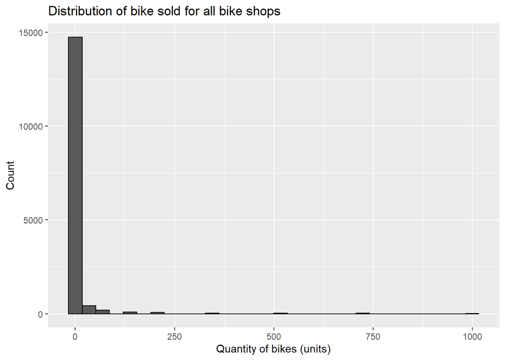

```r
bike_sales |>
  ggplot() +
  geom_histogram(aes(x = quantity),
                 color = "black") +
  labs(x = "Quantity of bikes (units)",
       y = "Count",
       title = "Distribution of bike sold for all bike shops")
```

#### 1.5.1.2 Price behavior

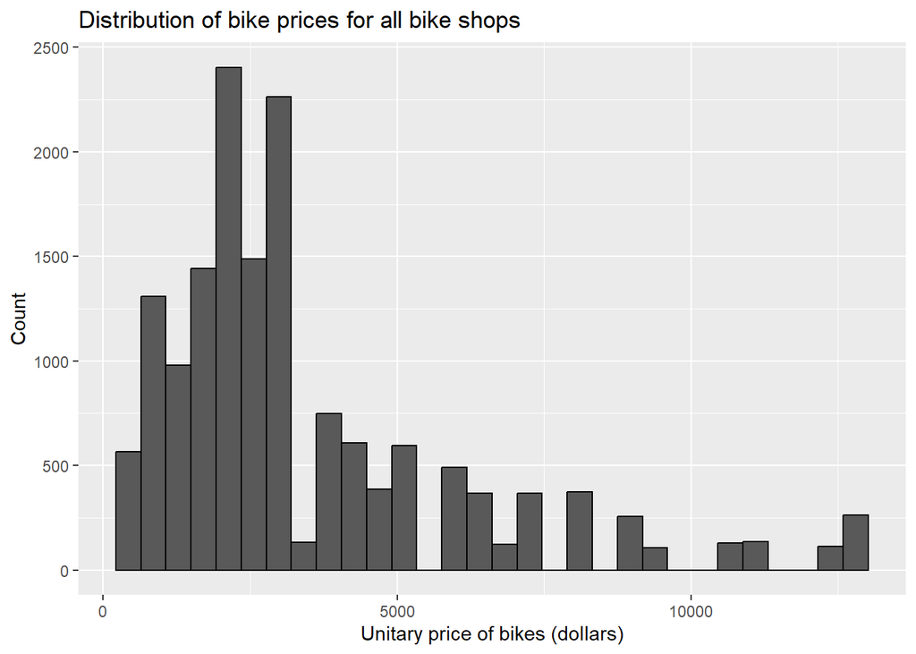

```r
bike_sales |>
  ggplot() +
  geom_histogram(aes(x = price),
                 color = "black") +
  labs(x = "Unitary price of bikes (dollars)",
       y = "Count",
       title = "Distribution of bike prices for all bike shops")
```

### 1.5.2 Boxplots

In this section generate 2 boxplots to explore the following items and point out the main finding in relation to these visualizations:

- Examine the revenue generated by the corporation, `price.ext`, according to the specific bicycle categories, `category.secondary`

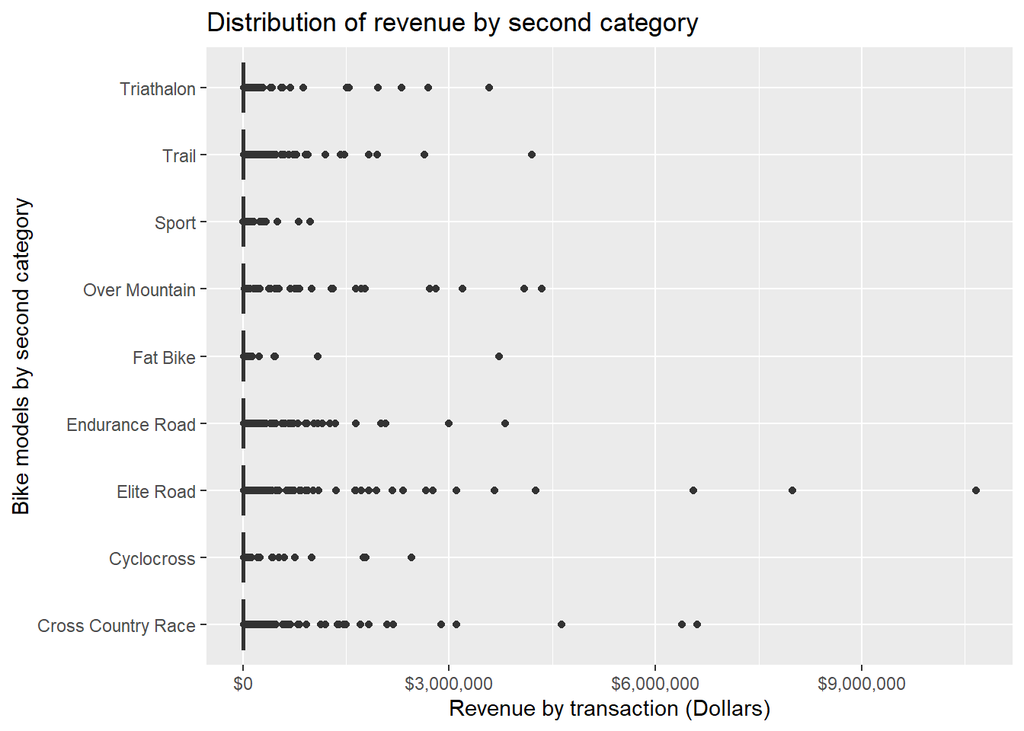

```r
bike_sales |>
  ggplot() +
  geom_boxplot(aes(x = price.ext,
                   y = category.secondary)) +
  scale_x_continuous(labels = scales::label_dollar()) +
  labs(x = "Revenue by transaction (Dollars)",
       y = "Bike models by second category",
       title = "Distribution of revenue by second category")
```

- Examine the revenue generated by the corporation, `price.ext`, according to the bicycle frame material, `frame`

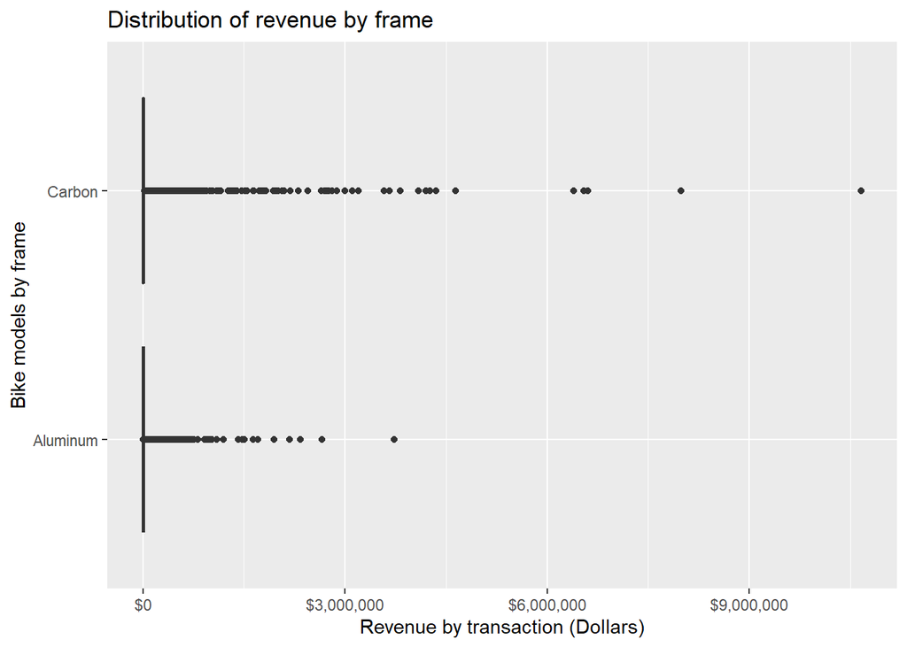

```r
bike_sales |>
  ggplot() +
  geom_boxplot(aes(x = price.ext,
                   y = frame)) +
  scale_x_continuous(labels = scales::label_dollar()) +
  labs(x = "Revenue by transaction (Dollars)",
       y = "Bike models by frame",
       title = "Distribution of revenue by frame")
```

## 1.6 Questions answered with data

This is a miscellaneous section where the idea is to answer questions using the `bike_sales` data set. Answer the following questions using the `tidyverse` and the functions `group_by`, `summarise`, `mutate`, `fct_reorder`, `ggplot` and `geom_col`:

- What are the bike shops, `bikeshop.name`, that generate more revenue, `price.ext`, to the corporation?

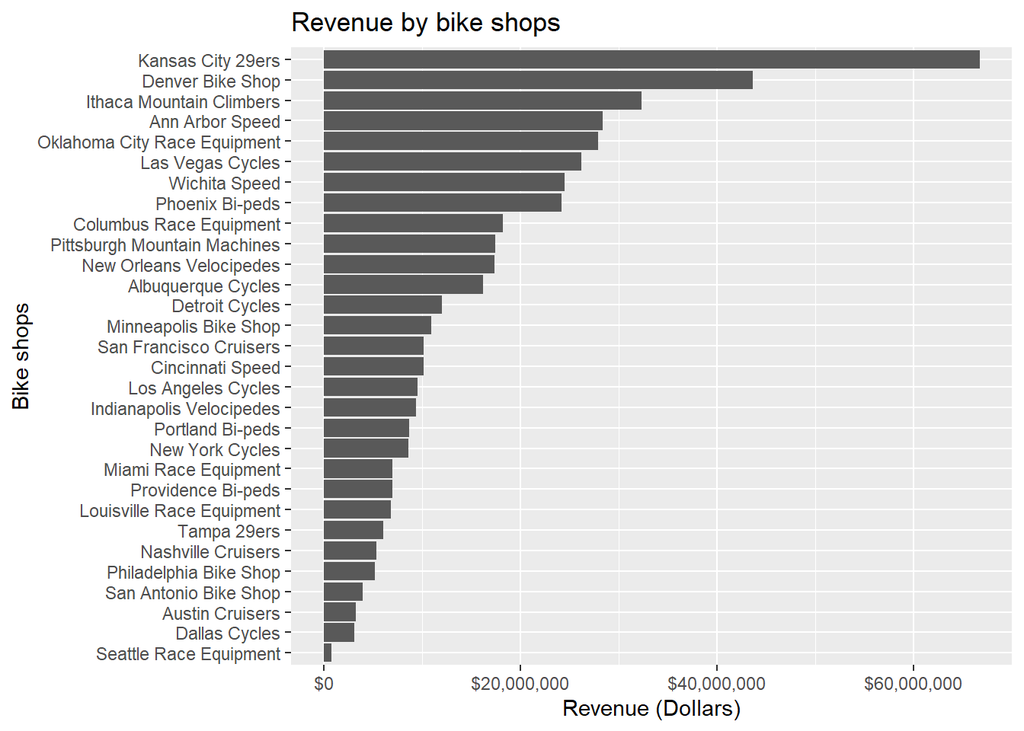

```r
# Checking revenue by customer
bike_sales_by_bikeshop_revenue <- bike_sales |>
  select(bikeshop.name, price.ext) |>
  group_by(bikeshop.name) |>
  summarise(total_revenue = sum(price.ext)) |>
  arrange(desc(total_revenue))

bike_sales_by_bikeshop_revenue |>
  mutate(bikeshop.name = fct_reorder(bikeshop.name,
                                     total_revenue)) |>
  ggplot() +
  geom_col(aes(x = total_revenue,
               y = bikeshop.name)) +
  scale_x_continuous(labels = scales::label_dollar()) +
  labs(x = "Revenue (Dollars)",
       y = "Bike shops",
       title = "Revenue by bike shops")
```

- What are the specific bicycle categories, `category.secondary`, that generate more revenue, `price.ext`, to the corporation?

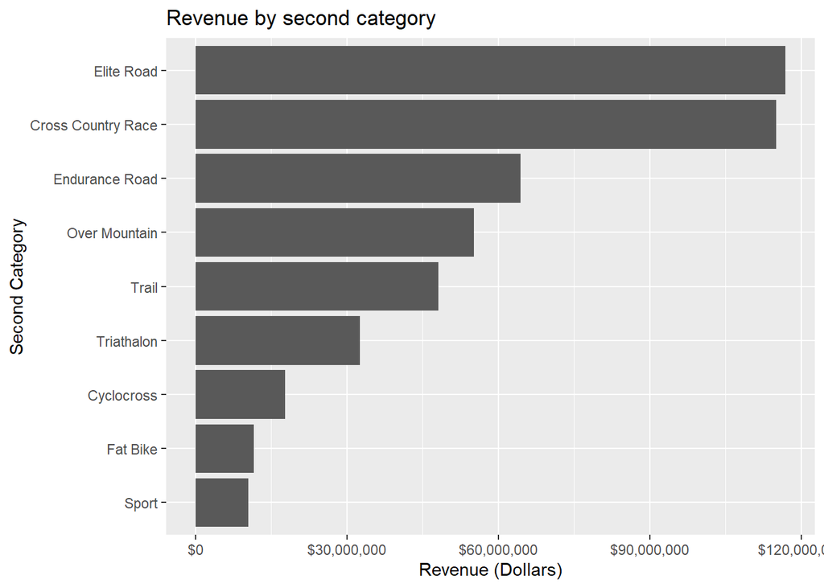

```r
# Checking revenue by second category
bike_sales_by_bikeshop_second_category <- bike_sales |>
  select(category.secondary, price.ext) |>
  group_by(category.secondary) |>
  summarise(total_revenue = sum(price.ext)) |>
  arrange(desc(total_revenue))

bike_sales_by_bikeshop_second_category |>
  mutate(category.secondary = fct_reorder(category.secondary,
                                     total_revenue)) |>
  ggplot() +
  geom_col(aes(x = total_revenue,
               y = category.secondary)) +
  scale_x_continuous(labels = scales::label_dollar()) +
  labs(x = "Revenue (Dollars)",
       y = "Second Category",
       title = "Revenue by second category")
```